# Summary and discussion

Workflow for the analysis of genomics populations and environmental variables for *Quercus macdougallii* under construction

# Analysis of environmental variables

## Analysis of environment variables

Below are the steps for the analysis of the environmental variables obtained in WorldClim, as well as the selection of the environmental variables with the lowest correlation for downstream analysis.

For this analysis the libraries were used: install.packages (“raster”) install.packages (“dismo”) install.packages (“rJava”) install.packages (“spocc”) install.packages (“rgbif”) install.packages (“rgeos”)

The 19 current environmental variables were obtained from the [WorldClim portal](https://www.worldclim.org/)

First we need to clean the data wich is remove spatially repeated data in a radius of 1km2. This is in the script **2.1_clean_data.R**

```r
source("../bin/2.1_clean_data.R", echo = T)
```

```
> #First we need to clean work space
> rm(list=ls())

> #Then we call the libraries
> library(sp)

> ############ Upload the file .csv, the presence data of the specie in UTM format #####################
> metadata_inds <- read.csv("../metadata/Qmac ..." ... [TRUNCATED]

> #This is just to detect duplicates
> dups <- duplicated(metadata_inds[, c("specie", "long", "lat")])

> sum(dups)
[1] 0

>   ### Del archivo de metadata extraemos solo el nombre de la especie y las coordenadas de los individuos
> species<-metadata_inds$specie

> lat<-metadata_inds$lat

> lon<-metadata_inds$long

> data<-data.frame(species,lon,lat)

> # Remove spacially repeated data in a radius of 1km2
> # This number, 0.00833, I take it from the properties of the Worldclim layers that I will use .... [TRUNCATED]

> # Function to create objects of class SpatialPointsDataFrame and remove duplicates
> clean_dup <- function(data,longitude,latitude,threshold=0.0){   .... [TRUNCATED]

> ### We have spatially clean data with the function clean_dup in accordance with the resolution already established
> data_clean <- clean_dup(data,lo .... [TRUNCATED]

> data_clean
         species      lon     lat
1  Qmacdougallii -96.4340 17.3925
4  Qmacdougallii -96.4488 17.3787
26 Qmacdougallii -96.4792 17.3943
30 Qmacdougallii -96.5072 17.5795
50 Qmacdougallii -96.5156 17.5815
70 Qmacdougallii -96.5326 17.6117
79 Qmacdougallii -96.5246 17.6152

> ### We can save this data in a new database that we will use for downstream analysis
> write.csv(data_clean, file = "../results/databases/q_macd_1km ..." ... [TRUNCATED]
```

```r
source("../bin/2.2_values_extraction.R", echo = T)
```

```
> #First we need to clean work space
> rm(list=ls())

> #Then we call the libraries
>
> library(sp)

> library(raster)

> ##directorio de las capas climaticas del presente
> wc_path <- list.files("../metadata/climate/wc/actual/",pattern = "*.asc$",full.names = T)###crea .... [TRUNCATED]

> layers_present<- stack(wc_path)

> #Cargar la base de datos, por ejemplo (primero para archivos de texto, segundo para archivos csv):
> ###directorio de los puntos de presencia
> meta .... [TRUNCATED]

> ###########Crear archivo CSV para los puntos a usar en los modelos####
> species<-metadata_inds$specie

> lat<-metadata_inds$lat

> lon<-metadata_inds$lon

> Specie_studied<-data.frame(species,lon,lat)

> values_clim <- data.frame(extract(layers_present,Specie_studied[,2:3]))###extrae los valores climaticos para cada uno de los puntos de presencia

> values_clim2<-data.frame(Specie_studied,values_clim)

> values_clim3 <- na.omit(values_clim2)## omite mis datos de presencia sin valores climaticos.

> #setwd("./limpios")##carpeta donde guardar el archivo .csv
> write.csv(values_clim3, file = "../results/databases/q_macd_wc_values.csv") ### para gu .... [TRUNCATED]
```

```
> #############################################################################################
> #First we need to clean work space
> rm(list=ls())

> #Load the library for VIF
> library(usdm)

> #Load the database
> values_clim<- read.csv("../results/databases/q_macd_wc_values.csv")

> ### Matriz de colinearidad
> cormatriz <- cor(values_clim[,5:23])#Definir cu?les son las columnas con las variables para hacer la correlaci?n (de la .... [TRUNCATED]

> png("../results/figures/Qmacdougallii_WC_var_correlation.png")

> #windows()
> corrplot(cormatriz, order = "hclust", method = "color",  type = "upper" , outline = F, tl.col = "black")

> dev.off()
null device
          1

> corrplot(cormatriz, order = "hclust", method = "color",  type = "upper" , outline = F, tl.col = "black")

> ### Para saber cuales quitar mediante el Factor de inflación de Varianza (VIF). si VIF>4.0 implica multicolinearidad, hay que remover esas variables .... [TRUNCATED]
   Variables VIF
1      bio01 Inf
2      bio02 Inf
3      bio03 Inf
4      bio04 Inf
5      bio05 Inf
6      bio06 Inf
7      bio07 Inf
8      bio08 Inf
9      bio09 Inf
10     bio10 Inf
11     bio11 Inf
12     bio12 Inf
13     bio13 Inf
14     bio14 Inf
15     bio15 Inf
16     bio16 Inf
17     bio17 Inf
18     bio18 Inf
19     bio19 Inf

> # Priemro vemos si hay alta colinearidad entre variables
> # De ser alta (mayor a 10 o el valor que se fije por el usuario) entonces se usa una redu .... [TRUNCATED]

> # th: es el valor de umbral deseado;Para ver cuáles fueron las variables que quedaron sin colinearidad
> no_corr
17 variables from the 19 input variables have collinearity problem:

bio01 bio02 bio03 bio04 bio05 bio06 bio07 bio08 bio09 bio10 bio11 bio12 bio13 bio17 bio19 bio18 bio14

After excluding the collinear variables, the linear correlation coefficients ranges between:
min correlation ( bio16 ~ bio15 ):  -0.4293385
max correlation ( bio16 ~ bio15 ):  -0.4293385

---------- VIFs of the remained variables --------
```

| Variables | VIF |
| --- | --- |
| bio15 | 1.225988 |
| bio16 | 1.225988 |

```
> # No se como guardarlo :( en archivo de texto write(no_corr, file = "abronia_mar_nocorr.txt")
>
```

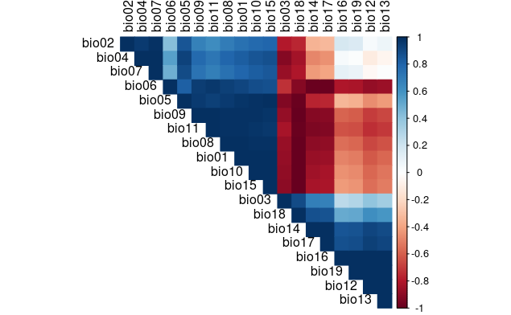

```r
source("../bin/2.3_variable_correlation.R", echo = T)
```